# Bivariate analysis

Bivariate analysis

Boxplots

Pairplots

Published

September 2, 2024

- **M1 MIDS & MFA**
- **[Université Paris Cité](https://www.u-paris.fr)**
- Année 2024-2025
- [Course Homepage](https://s-v-b.github.io/MA7BY020)
- [Moodle](https://moodle.u-paris.fr/course/view.php?id=6143)

**Objectives**

In Exploratory analysis of tabular data, bivariate analysis is the second step. It consists in exploring, summarizing, visualizing pairs of columns of a dataset.

## Setup

```r
stopifnot(
  require(tidyverse),
  require(glue),
  require(magrittr),
  require(lobstr),
  require(arrow),
  require(ggforce),
  require(vcd),
  require(ggmosaic),
  require(httr),
  require(cowplot),
  require(patchwork)
)
```

Bivariate techniques depend on the types of columns we are facing.

For *numerical/numerical* samples

- Scatter plots
- Smoothed lineplots (for example linear regression)
- 2-dimensional density plots

For *categorical/categorical* samples : mosaicplots and variants

For *numerical/categorical* samples

- Boxplots per group
- Histograms per group
- Density plots per group
- Quantile-Quantile plots

# Dataset

Once again we rely on the Census dataset.

> Since 1948, the US Census Bureau carries out a monthly Current Population Survey, collecting data concerning residents aged above 15 from $150 000$ households. This survey is one of the most important sources of information concerning the american workforce. Data reported in file `Recensement.txt` originate from the 2012 census.

Load the data into the session environment and call it `df`. Take advantage of the fact that we saved the result of our data wrangling job in a self-documented file format. Download a `parquet` file from the following URL:

`https://stephane-v-boucheron.fr/data/Recensement.parquet`

Use `httr::GET()` and `WriteBin()`.

# Categorical/Categorical pairs

```r
df |>
  select(where(is.factor)) |>
  head()
```

```
# A tibble: 6 × 9
  SEXE  REGION STAT_MARI SYNDICAT CATEGORIE  NIV_ETUDES NB_PERS NB_ENF REV_FOYER
  <fct> <fct>  <fct>     <fct>    <fct>      <fct>      <fct>   <fct>  <fct>
1 F     NE     C         non      "Administ… Bachelor   2       0      [35000-4…
2 M     W      M         non      "Building… 12 years … 2       0      [17500-2…
3 M     S      C         non      "Administ… Associate… 2       0      [75000-1…
4 M     NE     D         oui      "Services" 12 years … 4       1      [17500-2…
5 M     W      M         non      "Services" 9 years s… 8       1      [75000-1…
6 M     NW     C         non      "Services" 12 years … 6       0      [1e+05-1…
```

Explore the connection between `CATEGORIE` and `SEX`. Compute the 2-ways contingency table using `table()`, and `count()` from `dplyr`.

Use `tibble::as_tibble()` to transform the output of `table()` into a dataframe/tibble.

Use `tidyr::pivot_wider()` so as to obtain a wide (but messy) tibble with the same the same shape as the output of `table()`. Can you spot a difference?

Use `mosaicplot()` from base `R` to visualize the contingency table.

Use `geom_mosaic` from `ggmosaic` to visualize the contingency table

- Make the plot as readable as possible
- Reorder `CATEGORIE` acccording to counts
- Collapse rare levels of `CATEGORIE` (consider that a level is rare if it has less than 40 occurrences). Use tools from `forcats`.

# Testing association

## Chi-square independence/association test

# Categorical/Numerical pairs

## Grouped boxplots

Plot boxplots of `AGE` according to `NIV_ETUDES`

Draw density plots of `AGE`, facet by `NIV_ETUDES` and `SEXE`

Collapse rare levels of `NIV_ETUDES` and replay.

# Numerical/Numerical pairs

Make a scatterplot of `SAL_HOR`with respect to `AGE`

# Useful links

- rmarkdown
- [dplyr](https://gplot2.tidyverse.org)
- [ggplot2](https://ggplot2.tidyverse.org)
- *R Graphic Cookbook*. Winston Chang. O’ Reilly.
- [A blog on ggplot object](https://www.data-imaginist.com/2017/Beneath-the-canvas/)
- `skimr`
- `vcd`
- `ggmosaic`
- `ggforce`
- `arrow`
- `httr`

```r
expand.grid(levels(df$CATEGORIE), levels(df$SEXE))
```

```
                               Var1 Var2
1  Business, Management and Finance    F
2                Liberal profession    F
3                          Services    F
4                           Selling    F
5                    Administration    F
6                 Primary-Secondary    F
7  Business, Management and Finance    M
8                Liberal profession    M
9                          Services    M
10                          Selling    M
11                   Administration    M
12                Primary-Secondary    M
```

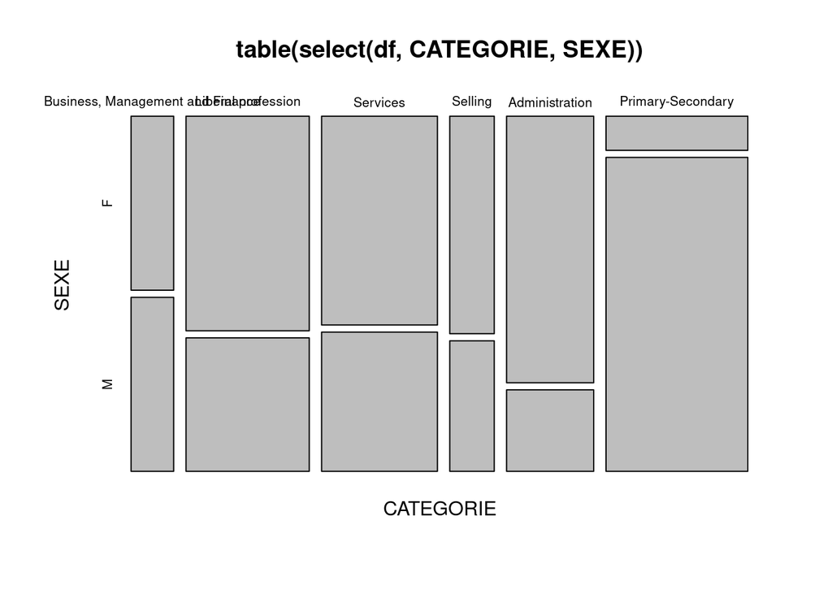

```r
df |>
  select(CATEGORIE, SEXE) |>
  table() |>
  mosaicplot()
```

```r
pchisq(140, df=5, lower.tail = F)
```

```
[1] 1.789245e-28
```